# Part I - (ford go bike-trip)

## by (Aboubacar SAWADOGO)

## Introduction

> cet ensemble de données comprend des informations sur les trajets individuels effectués dans un système de partage de vélos couvrant la grande région de la baie de San Francisco.Il est contenu dans un fichier 201902-fordgobike-tripdata.csvtéléchargé depuis https://video.udacity-data.com/topher/2020/October/5f91cf38_201902-fordgobike-tripdata/201902-fordgobike-tripdata.csv

> **Rubric Tip**: Your code should not generate any errors, and should use functions, loops where possible to reduce repetitive code. Prefer to use functions to reuse code statements.

> **Rubric Tip**: Document your approach and findings in markdown cells. Use comments and docstrings in code cells to document the code functionality.

> **Rubric Tip**: Markup cells should have headers and text that organize your thoughts, findings, and what you plan on investigating next.

## Preliminary Wrangling

> Load in your dataset and describe its properties through the questions below. Try and motivate your exploration goals through this section.

```
(183412, 16)


duration_sec                 int64
start_time                  object
end_time                    object
start_station_id           float64
start_station_name          object
start_station_latitude     float64
start_station_longitude    float64
end_station_id             float64
end_station_name            object
end_station_latitude       float64
end_station_longitude      float64
bike_id                      int64
user_type                   object
member_birth_year          float64
member_gender               object
bike_share_for_all_trip     object
dtype: object
```

|  | duration_sec | start_time | end_time | start_station_id | start_station_name | start_station_latitude | start_station_longitude | end_station_id | end_station_name | end_station_latitude | end_station_longitude | bike_id | user_type | member_birth_year | member_gender | bike_share_for_all_trip |
| --- | --- | --- | --- | --- | --- | --- | --- | --- | --- | --- | --- | --- | --- | --- | --- | --- |
| 0 | 52185 | 2019-02-28 17:32:10.1450 | 2019-03-01 08:01:55.9750 | 21.0 | Montgomery St BART Station (Market St at 2nd St) | 37.789625 | -122.400811 | 13.0 | Commercial St at Montgomery St | 37.794231 | -122.402923 | 4902 | Customer | 1984.0 | Male | No |
| 1 | 42521 | 2019-02-28 18:53:21.7890 | 2019-03-01 06:42:03.0560 | 23.0 | The Embarcadero at Steuart St | 37.791464 | -122.391034 | 81.0 | Berry St at 4th St | 37.775880 | -122.393170 | 2535 | Customer | NaN | NaN | No |
| 2 | 61854 | 2019-02-28 12:13:13.2180 | 2019-03-01 05:24:08.1460 | 86.0 | Market St at Dolores St | 37.769305 | -122.426826 | 3.0 | Powell St BART Station (Market St at 4th St) | 37.786375 | -122.404904 | 5905 | Customer | 1972.0 | Male | No |
| 3 | 36490 | 2019-02-28 17:54:26.0100 | 2019-03-01 04:02:36.8420 | 375.0 | Grove St at Masonic Ave | 37.774836 | -122.446546 | 70.0 | Central Ave at Fell St | 37.773311 | -122.444293 | 6638 | Subscriber | 1989.0 | Other | No |
| 4 | 1585 | 2019-02-28 23:54:18.5490 | 2019-03-01 00:20:44.0740 | 7.0 | Frank H Ogawa Plaza | 37.804562 | -122.271738 | 222.0 | 10th Ave at E 15th St | 37.792714 | -122.248780 | 4898 | Subscriber | 1974.0 | Male | Yes |
| 5 | 1793 | 2019-02-28 23:49:58.6320 | 2019-03-01 00:19:51.7600 | 93.0 | 4th St at Mission Bay Blvd S | 37.770407 | -122.391198 | 323.0 | Broadway at Kearny | 37.798014 | -122.405950 | 5200 | Subscriber | 1959.0 | Male | No |
| 6 | 1147 | 2019-02-28 23:55:35.1040 | 2019-03-01 00:14:42.5880 | 300.0 | Palm St at Willow St | 37.317298 | -121.884995 | 312.0 | San Jose Diridon Station | 37.329732 | -121.901782 | 3803 | Subscriber | 1983.0 | Female | No |
| 7 | 1615 | 2019-02-28 23:41:06.7660 | 2019-03-01 00:08:02.7560 | 10.0 | Washington St at Kearny St | 37.795393 | -122.404770 | 127.0 | Valencia St at 21st St | 37.756708 | -122.421025 | 6329 | Subscriber | 1989.0 | Male | No |
| 8 | 1570 | 2019-02-28 23:41:48.7900 | 2019-03-01 00:07:59.7150 | 10.0 | Washington St at Kearny St | 37.795393 | -122.404770 | 127.0 | Valencia St at 21st St | 37.756708 | -122.421025 | 6548 | Subscriber | 1988.0 | Other | No |
| 9 | 1049 | 2019-02-28 23:49:47.6990 | 2019-03-01 00:07:17.0250 | 19.0 | Post St at Kearny St | 37.788975 | -122.403452 | 121.0 | Mission Playground | 37.759210 | -122.421339 | 6488 | Subscriber | 1992.0 | Male | No |

|  | duration_sec | start_station_id | start_station_latitude | start_station_longitude | end_station_id | end_station_latitude | end_station_longitude | bike_id | member_birth_year |
| --- | --- | --- | --- | --- | --- | --- | --- | --- | --- |
| count | 183412.000000 | 183215.000000 | 183412.000000 | 183412.000000 | 183215.000000 | 183412.000000 | 183412.000000 | 183412.000000 | 175147.000000 |
| mean | 726.078435 | 138.590427 | 37.771223 | -122.352664 | 136.249123 | 37.771427 | -122.352250 | 4472.906375 | 1984.806437 |
| std | 1794.389780 | 111.778864 | 0.099581 | 0.117097 | 111.515131 | 0.099490 | 0.116673 | 1664.383394 | 10.116689 |
| min | 61.000000 | 3.000000 | 37.317298 | -122.453704 | 3.000000 | 37.317298 | -122.453704 | 11.000000 | 1878.000000 |
| 25% | 325.000000 | 47.000000 | 37.770083 | -122.412408 | 44.000000 | 37.770407 | -122.411726 | 3777.000000 | 1980.000000 |
| 50% | 514.000000 | 104.000000 | 37.780760 | -122.398285 | 100.000000 | 37.781010 | -122.398279 | 4958.000000 | 1987.000000 |
| 75% | 796.000000 | 239.000000 | 37.797280 | -122.286533 | 235.000000 | 37.797320 | -122.288045 | 5502.000000 | 1992.000000 |
| max | 85444.000000 | 398.000000 | 37.880222 | -121.874119 | 398.000000 | 37.880222 | -121.874119 | 6645.000000 | 2001.000000 |

```
Market St at 10th St                                               3904
San Francisco Caltrain Station 2  (Townsend St at 4th St)          3544
Berry St at 4th St                                                 3052
Montgomery St BART Station (Market St at 2nd St)                   2895
Powell St BART Station (Market St at 4th St)                       2760
San Francisco Ferry Building (Harry Bridges Plaza)                 2710
San Francisco Caltrain (Townsend St at 4th St)                     2703
Powell St BART Station (Market St at 5th St)                       2327
Howard St at Beale St                                              2293
Steuart St at Market St                                            2283
The Embarcadero at Sansome St                                      2082
Bancroft Way at Telegraph Ave                                      1796
Bancroft Way at College Ave                                        1770
2nd St at Townsend St                                              1765
3rd St at Townsend St                                              1753
Embarcadero BART Station (Beale St at Market St)                   1746
Beale St at Harrison St                                            1719
Civic Center/UN Plaza BART Station (Market St at McAllister St)    1611
Townsend St at 7th St                                              1573
4th St at Mission Bay Blvd S                                       1552
The Embarcadero at Steuart St                                      1458
Post St at Kearny St                                               1376
Downtown Berkeley BART                                             1375
4th St at 16th St                                                  1360
Howard St at 8th St                                                1314
Rhode Island St at 17th St                                         1303
Esprit Park                                                        1290
19th Street BART Station                                           1276
Hearst Ave at Euclid Ave                                           1203
8th St at Brannan St                                               1203
                                                                   ...
Newhall St at 3rd St                                                 57
45th St at MLK Jr Way                                                55
27th St at MLK Jr Way                                                55
San Antonio Park                                                     53
Williams Ave at 3rd St                                               50
Delmas Ave and San Fernando St                                       50
Locust St at Grant St                                                49
San Carlos St at Market St                                           48
Lane St at Revere Ave                                                36
Foothill Blvd at Harrington Ave                                      35
Almaden Blvd at Balbach St                                           34
Mission St at 1st St                                                 34
SAP Center                                                           32
George St at 1st St                                                  31
Oak St at 1st St                                                     30
Empire St at 7th St                                                  29
Williams Ave at Apollo St                                            25
Foothill Blvd at 42nd Ave                                            23
26th Ave at International Blvd                                       19
San Pedro St at Hedding St                                           19
Farnam St at Fruitvale Ave                                           18
23rd Ave at Foothill Blvd                                            18
Leavenworth St at Broadway                                           17
Backesto Park (Jackson St at 13th St)                                17
Taylor St at 9th St                                                  13
Willow St at Vine St                                                  9
Parker Ave at McAllister St                                           7
Palm St at Willow St                                                  4
21st Ave at International Blvd                                        4
16th St Depot                                                         2
Name: start_station_name, Length: 329, dtype: int64
```

```
<class 'pandas.core.frame.DataFrame'>
RangeIndex: 183412 entries, 0 to 183411
Data columns (total 16 columns):
duration_sec               183412 non-null int64
start_time                 183412 non-null object
end_time                   183412 non-null object
start_station_id           183215 non-null float64
start_station_name         183215 non-null object
start_station_latitude     183412 non-null float64
start_station_longitude    183412 non-null float64
end_station_id             183215 non-null float64
end_station_name           183215 non-null object
end_station_latitude       183412 non-null float64
end_station_longitude      183412 non-null float64
bike_id                    183412 non-null int64
user_type                  183412 non-null object
member_birth_year          175147 non-null float64
member_gender              175147 non-null object
bike_share_for_all_trip    183412 non-null object
dtypes: float64(7), int64(2), object(7)
memory usage: 22.4+ MB
```

### What is the structure of your dataset?

> ```
> La structure du jeu de données contient 16 colonnes et 183 412 lignes.
> La plupart des variables sont de nature numérique.
> ```

### What is/are the main feature(s) of interest in your dataset?

> Nous avons trois principaux domaines de fonctionnalités qui sont :
> - durée du trajet (temps)
> - sexe du membre
> - âge du membre

### What features in the dataset do you think will help support your investigation into your feature(s) of interest?

> ```
> - user_type
> - bike_share_for_all_trip
> - member_gender
> - member_birth_year ( age)
> - duration_sec (duration minutes / hours )
> ```

# Explorons de manière aprofondit les données

[output not shown]

```
Index(['duration_sec', 'start_time', 'end_time', 'start_station_id',
       'start_station_name', 'start_station_latitude',
       'start_station_longitude', 'end_station_id', 'end_station_name',
       'end_station_latitude', 'end_station_longitude', 'bike_id', 'user_type',
       'member_birth_year', 'member_gender', 'bike_share_for_all_trip'],
      dtype='object')
```

```
<class 'pandas.core.frame.DataFrame'>
RangeIndex: 183412 entries, 0 to 183411
Data columns (total 16 columns):
duration_sec               183412 non-null int64
start_time                 183412 non-null object
end_time                   183412 non-null object
start_station_id           183215 non-null float64
start_station_name         183215 non-null object
start_station_latitude     183412 non-null float64
start_station_longitude    183412 non-null float64
end_station_id             183215 non-null float64
end_station_name           183215 non-null object
end_station_latitude       183412 non-null float64
end_station_longitude      183412 non-null float64
bike_id                    183412 non-null int64
user_type                  183412 non-null object
member_birth_year          175147 non-null float64
member_gender              175147 non-null object
bike_share_for_all_trip    183412 non-null object
dtypes: float64(7), int64(2), object(7)
memory usage: 22.4+ MB
```

Nous remarquons que certaines colonnes ont des valeurs manquantes

Etudions celà

```
duration_sec                  0
start_time                    0
end_time                      0
start_station_id            197
start_station_name          197
start_station_latitude        0
start_station_longitude       0
end_station_id              197
end_station_name            197
end_station_latitude          0
end_station_longitude         0
bike_id                       0
user_type                     0
member_birth_year          8265
member_gender              8265
bike_share_for_all_trip       0
dtype: int64
```

```
array(['Customer', 'Subscriber'], dtype=object)
```

# Nettoyons les données

```
duration_sec               0
start_time                 0
end_time                   0
start_station_id           0
start_station_name         0
start_station_latitude     0
start_station_longitude    0
end_station_id             0
end_station_name           0
end_station_latitude       0
end_station_longitude      0
bike_id                    0
user_type                  0
member_birth_year          0
member_gender              0
bike_share_for_all_trip    0
dtype: int64
```

Bonne nouvelle, PLus de valeur null

[output not shown]

[output not shown]

|  | duration_min | start_time | end_time | start_station_id | start_station_name | start_station_latitude | start_station_longitude | end_station_id | end_station_name | end_station_latitude | end_station_longitude | bike_id | user_type | member_birth_year | member_gender | bike_share_for_all_trip |
| --- | --- | --- | --- | --- | --- | --- | --- | --- | --- | --- | --- | --- | --- | --- | --- | --- |
| 1285 | 0.041111 | 2019-02-28 19:29:17.627 | 2019-02-28 19:31:45.967 | 158.0 | Shattuck Ave at Telegraph Ave | 37.833279 | -122.263490 | 173.0 | Shattuck Ave at 55th St | 37.840364 | -122.264488 | 5391 | Subscriber | 1900.0 | Male | Yes |
| 5197 | 0.060278 | 2019-02-28 13:51:46.238 | 2019-02-28 13:55:24.127 | 70.0 | Central Ave at Fell St | 37.773311 | -122.444293 | 71.0 | Broderick St at Oak St | 37.773063 | -122.439078 | 5801 | Subscriber | 1931.0 | Male | No |
| 5266 | 0.106667 | 2019-02-28 13:35:05.428 | 2019-02-28 13:41:30.223 | 84.0 | Duboce Park | 37.769201 | -122.433812 | 71.0 | Broderick St at Oak St | 37.773063 | -122.439078 | 6608 | Subscriber | 1931.0 | Male | No |
| 5447 | 0.040833 | 2019-02-28 13:08:56.935 | 2019-02-28 13:11:24.062 | 84.0 | Duboce Park | 37.769201 | -122.433812 | 72.0 | Page St at Scott St | 37.772406 | -122.435650 | 5018 | Subscriber | 1931.0 | Male | No |
| 10827 | 0.365278 | 2019-02-27 19:21:34.436 | 2019-02-27 19:43:30.008 | 343.0 | Bryant St at 2nd St | 37.783172 | -122.393572 | 375.0 | Grove St at Masonic Ave | 37.774836 | -122.446546 | 6249 | Subscriber | 1900.0 | Male | No |
| 16087 | 0.314167 | 2019-02-27 08:37:36.864 | 2019-02-27 08:56:28.022 | 375.0 | Grove St at Masonic Ave | 37.774836 | -122.446546 | 36.0 | Folsom St at 3rd St | 37.783830 | -122.398870 | 4968 | Subscriber | 1900.0 | Male | No |
| 17981 | 0.101667 | 2019-02-26 19:53:38.528 | 2019-02-26 19:59:44.968 | 50.0 | 2nd St at Townsend St | 37.780526 | -122.390288 | 21.0 | Montgomery St BART Station (Market St at 2nd St) | 37.789625 | -122.400811 | 5226 | Subscriber | 1920.0 | Male | No |
| 18885 | 0.120000 | 2019-02-26 17:48:59.016 | 2019-02-26 17:56:11.370 | 21.0 | Montgomery St BART Station (Market St at 2nd St) | 37.789625 | -122.400811 | 50.0 | 2nd St at Townsend St | 37.780526 | -122.390288 | 5319 | Subscriber | 1920.0 | Male | No |
| 19375 | 0.178056 | 2019-02-26 17:03:19.855 | 2019-02-26 17:14:01.619 | 9.0 | Broadway at Battery St | 37.798572 | -122.400869 | 30.0 | San Francisco Caltrain (Townsend St at 4th St) | 37.776598 | -122.395282 | 6164 | Customer | 1900.0 | Male | No |
| 20743 | 0.105556 | 2019-02-26 10:57:07.767 | 2019-02-26 11:03:28.196 | 26.0 | 1st St at Folsom St | 37.787290 | -122.394380 | 61.0 | Howard St at 8th St | 37.776513 | -122.411306 | 5387 | Subscriber | 1933.0 | Female | Yes |
| 21424 | 0.395556 | 2019-02-26 08:58:02.904 | 2019-02-26 09:21:47.749 | 375.0 | Grove St at Masonic Ave | 37.774836 | -122.446546 | 343.0 | Bryant St at 2nd St | 37.783172 | -122.393572 | 5344 | Subscriber | 1900.0 | Male | No |
| 21506 | 0.194722 | 2019-02-26 09:06:11.239 | 2019-02-26 09:17:52.442 | 67.0 | San Francisco Caltrain Station 2 (Townsend St... | 37.776639 | -122.395526 | 9.0 | Broadway at Battery St | 37.798572 | -122.400869 | 5337 | Customer | 1900.0 | Male | No |
| 24042 | 0.053889 | 2019-02-25 18:58:10.644 | 2019-02-25 19:01:25.308 | 158.0 | Shattuck Ave at Telegraph Ave | 37.833279 | -122.263490 | 173.0 | Shattuck Ave at 55th St | 37.840364 | -122.264488 | 6363 | Subscriber | 1900.0 | Male | Yes |
| 26133 | 0.113889 | 2019-02-25 13:38:12.067 | 2019-02-25 13:45:02.207 | 173.0 | Shattuck Ave at 55th St | 37.840364 | -122.264488 | 176.0 | MacArthur BART Station | 37.828410 | -122.266315 | 3311 | Subscriber | 1900.0 | Male | Yes |
| 26344 | 0.148333 | 2019-02-25 12:43:50.225 | 2019-02-25 12:52:45.128 | 26.0 | 1st St at Folsom St | 37.787290 | -122.394380 | 61.0 | Howard St at 8th St | 37.776513 | -122.411306 | 5948 | Subscriber | 1933.0 | Female | Yes |
| 26488 | 0.092778 | 2019-02-25 12:13:25.330 | 2019-02-25 12:18:59.434 | 71.0 | Broderick St at Oak St | 37.773063 | -122.439078 | 84.0 | Duboce Park | 37.769201 | -122.433812 | 3361 | Subscriber | 1931.0 | Male | No |
| 26535 | 0.033056 | 2019-02-25 12:08:38.311 | 2019-02-25 12:10:37.660 | 71.0 | Broderick St at Oak St | 37.773063 | -122.439078 | 53.0 | Grove St at Divisadero | 37.775946 | -122.437777 | 6475 | Subscriber | 1931.0 | Male | No |
| 26568 | 0.037500 | 2019-02-25 12:02:18.360 | 2019-02-25 12:04:34.272 | 71.0 | Broderick St at Oak St | 37.773063 | -122.439078 | 53.0 | Grove St at Divisadero | 37.775946 | -122.437777 | 6257 | Subscriber | 1931.0 | Male | No |
| 26604 | 0.081667 | 2019-02-25 11:52:12.537 | 2019-02-25 11:57:06.985 | 85.0 | Church St at Duboce Ave | 37.770083 | -122.429156 | 53.0 | Grove St at Divisadero | 37.775946 | -122.437777 | 5814 | Subscriber | 1931.0 | Male | No |
| 26641 | 0.021667 | 2019-02-25 11:50:14.777 | 2019-02-25 11:51:33.555 | 85.0 | Church St at Duboce Ave | 37.770083 | -122.429156 | 85.0 | Church St at Duboce Ave | 37.770083 | -122.429156 | 4361 | Subscriber | 1931.0 | Male | No |
| 26685 | 0.030556 | 2019-02-25 11:40:27.348 | 2019-02-25 11:42:17.782 | 85.0 | Church St at Duboce Ave | 37.770083 | -122.429156 | 73.0 | Pierce St at Haight St | 37.771793 | -122.433708 | 6208 | Subscriber | 1931.0 | Male | No |
| 26718 | 0.038333 | 2019-02-25 11:33:27.172 | 2019-02-25 11:35:45.176 | 71.0 | Broderick St at Oak St | 37.773063 | -122.439078 | 73.0 | Pierce St at Haight St | 37.771793 | -122.433708 | 6110 | Subscriber | 1931.0 | Male | No |
| 26757 | 0.022500 | 2019-02-25 11:25:52.753 | 2019-02-25 11:27:14.706 | 375.0 | Grove St at Masonic Ave | 37.774836 | -122.446546 | 70.0 | Central Ave at Fell St | 37.773311 | -122.444293 | 579 | Subscriber | 1931.0 | Male | No |
| 26775 | 0.036111 | 2019-02-25 11:21:03.469 | 2019-02-25 11:23:13.569 | 71.0 | Broderick St at Oak St | 37.773063 | -122.439078 | 70.0 | Central Ave at Fell St | 37.773311 | -122.444293 | 5354 | Subscriber | 1931.0 | Male | No |
| 26807 | 0.032222 | 2019-02-25 11:14:28.437 | 2019-02-25 11:16:25.262 | 375.0 | Grove St at Masonic Ave | 37.774836 | -122.446546 | 70.0 | Central Ave at Fell St | 37.773311 | -122.444293 | 74 | Subscriber | 1931.0 | Male | No |
| 26828 | 0.038611 | 2019-02-25 11:08:41.602 | 2019-02-25 11:11:01.559 | 71.0 | Broderick St at Oak St | 37.773063 | -122.439078 | 70.0 | Central Ave at Fell St | 37.773311 | -122.444293 | 1428 | Subscriber | 1931.0 | Male | No |
| 26906 | 0.022778 | 2019-02-25 10:54:23.321 | 2019-02-25 10:55:45.902 | 85.0 | Church St at Duboce Ave | 37.770083 | -122.429156 | 86.0 | Market St at Dolores St | 37.769305 | -122.426826 | 1916 | Subscriber | 1931.0 | Male | No |
| 26917 | 0.018611 | 2019-02-25 10:51:02.382 | 2019-02-25 10:52:09.394 | 85.0 | Church St at Duboce Ave | 37.770083 | -122.429156 | 86.0 | Market St at Dolores St | 37.769305 | -122.426826 | 2664 | Subscriber | 1931.0 | Male | No |
| 26935 | 0.061389 | 2019-02-25 10:45:01.973 | 2019-02-25 10:48:43.607 | 76.0 | McCoppin St at Valencia St | 37.771662 | -122.422423 | 86.0 | Market St at Dolores St | 37.769305 | -122.426826 | 5423 | Subscriber | 1931.0 | Male | No |
| 26981 | 0.034167 | 2019-02-25 10:38:50.650 | 2019-02-25 10:40:54.604 | 95.0 | Sanchez St at 15th St | 37.766219 | -122.431060 | 86.0 | Market St at Dolores St | 37.769305 | -122.426826 | 6582 | Subscriber | 1931.0 | Male | No |
| ... | ... | ... | ... | ... | ... | ... | ... | ... | ... | ... | ... | ... | ... | ... | ... | ... |
| 122172 | 0.166944 | 2019-02-11 12:41:30.503 | 2019-02-11 12:51:31.662 | 26.0 | 1st St at Folsom St | 37.787290 | -122.394380 | 61.0 | Howard St at 8th St | 37.776513 | -122.411306 | 5283 | Subscriber | 1933.0 | Female | Yes |
| 122194 | 0.460278 | 2019-02-11 12:19:26.064 | 2019-02-11 12:47:03.298 | 377.0 | Fell St at Stanyan St | 37.771917 | -122.453704 | 36.0 | Folsom St at 3rd St | 37.783830 | -122.398870 | 2197 | Subscriber | 1900.0 | Male | No |
| 123240 | 0.156111 | 2019-02-11 09:36:13.876 | 2019-02-11 09:45:36.806 | 30.0 | San Francisco Caltrain (Townsend St at 4th St) | 37.776598 | -122.395282 | 26.0 | 1st St at Folsom St | 37.787290 | -122.394380 | 4877 | Subscriber | 1902.0 | Female | No |
| 128986 | 0.144444 | 2019-02-10 11:48:51.152 | 2019-02-10 11:57:31.632 | 173.0 | Shattuck Ave at 55th St | 37.840364 | -122.264488 | 150.0 | Adeline St at 40th St | 37.831277 | -122.278267 | 2323 | Subscriber | 1900.0 | Male | Yes |
| 137804 | 0.103333 | 2019-02-08 08:22:24.741 | 2019-02-08 08:28:37.126 | 30.0 | San Francisco Caltrain (Townsend St at 4th St) | 37.776598 | -122.395282 | 26.0 | 1st St at Folsom St | 37.787290 | -122.394380 | 4617 | Subscriber | 1902.0 | Female | No |
| 138297 | 0.136389 | 2019-02-08 07:44:39.461 | 2019-02-08 07:52:51.140 | 284.0 | Yerba Buena Center for the Arts (Howard St at ... | 37.784872 | -122.400876 | 30.0 | San Francisco Caltrain (Townsend St at 4th St) | 37.776598 | -122.395282 | 5276 | Subscriber | 1901.0 | Male | No |
| 140748 | 0.133611 | 2019-02-07 18:41:11.650 | 2019-02-07 18:49:13.254 | 25.0 | Howard St at 2nd St | 37.787522 | -122.397405 | 30.0 | San Francisco Caltrain (Townsend St at 4th St) | 37.776598 | -122.395282 | 5476 | Subscriber | 1902.0 | Female | No |
| 144039 | 0.105000 | 2019-02-07 13:24:05.833 | 2019-02-07 13:30:23.947 | 26.0 | 1st St at Folsom St | 37.787290 | -122.394380 | 349.0 | Howard St at Mary St | 37.781010 | -122.405666 | 5485 | Subscriber | 1933.0 | Female | Yes |
| 145215 | 0.141389 | 2019-02-07 09:59:33.822 | 2019-02-07 10:08:03.480 | 349.0 | Howard St at Mary St | 37.781010 | -122.405666 | 27.0 | Beale St at Harrison St | 37.788059 | -122.391865 | 4811 | Subscriber | 1933.0 | Female | Yes |
| 145510 | 0.141111 | 2019-02-07 09:34:11.542 | 2019-02-07 09:42:40.400 | 30.0 | San Francisco Caltrain (Townsend St at 4th St) | 37.776598 | -122.395282 | 26.0 | 1st St at Folsom St | 37.787290 | -122.394380 | 5541 | Subscriber | 1902.0 | Female | No |
| 147519 | 0.127778 | 2019-02-07 07:44:28.217 | 2019-02-07 07:52:08.390 | 284.0 | Yerba Buena Center for the Arts (Howard St at ... | 37.784872 | -122.400876 | 30.0 | San Francisco Caltrain (Townsend St at 4th St) | 37.776598 | -122.395282 | 3646 | Subscriber | 1901.0 | Male | No |
| 149706 | 0.102778 | 2019-02-06 18:58:13.934 | 2019-02-06 19:04:24.912 | 118.0 | Eureka Valley Recreation Center | 37.759177 | -122.436943 | 84.0 | Duboce Park | 37.769201 | -122.433812 | 5334 | Subscriber | 1931.0 | Male | No |
| 150108 | 0.201944 | 2019-02-06 18:24:40.310 | 2019-02-06 18:36:48.183 | 81.0 | Berry St at 4th St | 37.775880 | -122.393170 | 284.0 | Yerba Buena Center for the Arts (Howard St at ... | 37.784872 | -122.400876 | 5356 | Subscriber | 1910.0 | Other | No |
| 151936 | 0.172778 | 2019-02-06 16:42:11.928 | 2019-02-06 16:52:34.230 | 25.0 | Howard St at 2nd St | 37.787522 | -122.397405 | 30.0 | San Francisco Caltrain (Townsend St at 4th St) | 37.776598 | -122.395282 | 560 | Subscriber | 1902.0 | Female | No |
| 157035 | 0.093056 | 2019-02-06 06:36:44.481 | 2019-02-06 06:42:20.308 | 84.0 | Duboce Park | 37.769201 | -122.433812 | 118.0 | Eureka Valley Recreation Center | 37.759177 | -122.436943 | 3303 | Subscriber | 1931.0 | Male | No |
| 159405 | 0.162222 | 2019-02-05 17:59:16.244 | 2019-02-05 18:09:00.940 | 26.0 | 1st St at Folsom St | 37.787290 | -122.394380 | 5.0 | Powell St BART Station (Market St at 5th St) | 37.783899 | -122.408445 | 5098 | Subscriber | 1933.0 | Female | Yes |
| 161505 | 0.098611 | 2019-02-05 14:43:59.227 | 2019-02-05 14:49:54.267 | 25.0 | Howard St at 2nd St | 37.787522 | -122.397405 | 30.0 | San Francisco Caltrain (Townsend St at 4th St) | 37.776598 | -122.395282 | 4928 | Subscriber | 1902.0 | Female | No |
| 162051 | 0.048889 | 2019-02-05 13:00:00.604 | 2019-02-05 13:02:57.549 | 173.0 | Shattuck Ave at 55th St | 37.840364 | -122.264488 | 174.0 | Shattuck Ave at 51st St | 37.836801 | -122.264004 | 2442 | Subscriber | 1900.0 | Male | Yes |
| 163112 | 0.455556 | 2019-02-05 09:18:18.397 | 2019-02-05 09:45:39.016 | 377.0 | Fell St at Stanyan St | 37.771917 | -122.453704 | 36.0 | Folsom St at 3rd St | 37.783830 | -122.398870 | 2715 | Subscriber | 1900.0 | Male | No |
| 165505 | 0.070833 | 2019-02-05 06:52:54.194 | 2019-02-05 06:57:10.083 | 84.0 | Duboce Park | 37.769201 | -122.433812 | 118.0 | Eureka Valley Recreation Center | 37.759177 | -122.436943 | 5381 | Subscriber | 1931.0 | Male | No |
| 167178 | 0.146111 | 2019-02-04 17:36:54.155 | 2019-02-04 17:45:41.140 | 25.0 | Howard St at 2nd St | 37.787522 | -122.397405 | 30.0 | San Francisco Caltrain (Townsend St at 4th St) | 37.776598 | -122.395282 | 184 | Subscriber | 1902.0 | Female | No |
| 171086 | 0.301667 | 2019-02-04 06:30:33.383 | 2019-02-04 06:48:39.869 | 375.0 | Grove St at Masonic Ave | 37.774836 | -122.446546 | 36.0 | Folsom St at 3rd St | 37.783830 | -122.398870 | 4435 | Subscriber | 1900.0 | Male | No |
| 171757 | 0.026111 | 2019-02-03 19:12:06.607 | 2019-02-03 19:13:40.671 | 173.0 | Shattuck Ave at 55th St | 37.840364 | -122.264488 | 174.0 | Shattuck Ave at 51st St | 37.836801 | -122.264004 | 4539 | Subscriber | 1900.0 | Male | Yes |
| 171996 | 0.380000 | 2019-02-03 17:33:54.607 | 2019-02-03 17:56:42.949 | 37.0 | 2nd St at Folsom St | 37.785000 | -122.395936 | 375.0 | Grove St at Masonic Ave | 37.774836 | -122.446546 | 4988 | Subscriber | 1900.0 | Male | No |
| 173711 | 0.275833 | 2019-02-03 09:45:30.464 | 2019-02-03 10:02:04.169 | 375.0 | Grove St at Masonic Ave | 37.774836 | -122.446546 | 36.0 | Folsom St at 3rd St | 37.783830 | -122.398870 | 5445 | Subscriber | 1900.0 | Male | No |
| 177708 | 0.424167 | 2019-02-01 19:09:28.387 | 2019-02-01 19:34:55.963 | 343.0 | Bryant St at 2nd St | 37.783172 | -122.393572 | 375.0 | Grove St at Masonic Ave | 37.774836 | -122.446546 | 5286 | Subscriber | 1900.0 | Male | No |
| 177885 | 0.143611 | 2019-02-01 18:38:40.471 | 2019-02-01 18:47:18.392 | 25.0 | Howard St at 2nd St | 37.787522 | -122.397405 | 30.0 | San Francisco Caltrain (Townsend St at 4th St) | 37.776598 | -122.395282 | 2175 | Subscriber | 1902.0 | Female | No |
| 177955 | 0.104722 | 2019-02-01 18:23:33.411 | 2019-02-01 18:29:50.795 | 26.0 | 1st St at Folsom St | 37.787290 | -122.394380 | 321.0 | 5th St at Folsom | 37.780146 | -122.403071 | 5444 | Subscriber | 1933.0 | Female | Yes |
| 182830 | 0.118889 | 2019-02-01 07:45:05.934 | 2019-02-01 07:52:14.922 | 284.0 | Yerba Buena Center for the Arts (Howard St at ... | 37.784872 | -122.400876 | 67.0 | San Francisco Caltrain Station 2 (Townsend St... | 37.776639 | -122.395526 | 5031 | Subscriber | 1901.0 | Male | No |
| 183388 | 0.136111 | 2019-02-01 00:39:53.112 | 2019-02-01 00:48:03.338 | 61.0 | Howard St at 8th St | 37.776513 | -122.411306 | 81.0 | Berry St at 4th St | 37.775880 | -122.393170 | 5411 | Subscriber | 1927.0 | Male | No |

187 rows × 16 columns

|  | duration_min | start_station_id | start_station_latitude | start_station_longitude | end_station_id | end_station_latitude | end_station_longitude | bike_id | member_birth_year |
| --- | --- | --- | --- | --- | --- | --- | --- | --- | --- |
| count | 174765.000000 | 174765.000000 | 174765.000000 | 174765.000000 | 174765.000000 | 174765.000000 | 174765.000000 | 174765.000000 | 174765.000000 |
| mean | 11.738381 | 139.022110 | 37.771203 | -122.351719 | 136.642297 | 37.771398 | -122.351295 | 4482.302635 | 1984.873390 |
| std | 27.383484 | 111.648301 | 0.100441 | 0.117774 | 111.349664 | 0.100345 | 0.117337 | 1659.222103 | 9.881006 |
| min | 1.016667 | 3.000000 | 37.317298 | -122.453704 | 3.000000 | 37.317298 | -122.453704 | 11.000000 | 1934.000000 |
| 25% | 5.383333 | 47.000000 | 37.770407 | -122.411901 | 44.000000 | 37.770407 | -122.411647 | 3799.000000 | 1980.000000 |
| 50% | 8.516667 | 104.000000 | 37.780787 | -122.398279 | 101.000000 | 37.781010 | -122.397437 | 4960.000000 | 1987.000000 |
| 75% | 13.150000 | 239.000000 | 37.797320 | -122.283093 | 238.000000 | 37.797673 | -122.285633 | 5505.000000 | 1992.000000 |
| max | 1409.133333 | 398.000000 | 37.880222 | -121.874119 | 398.000000 | 37.880222 | -121.874119 | 6645.000000 | 2001.000000 |

```
0    35.0
2    47.0
3    30.0
4    45.0
5    60.0
Name: Age, dtype: float64
```

```
<class 'pandas.core.frame.DataFrame'>
Int64Index: 174765 entries, 0 to 183411
Data columns (total 17 columns):
duration_min               174765 non-null float64
start_time                 174765 non-null datetime64[ns]
end_time                   174765 non-null datetime64[ns]
start_station_id           174765 non-null float64
start_station_name         174765 non-null object
start_station_latitude     174765 non-null float64
start_station_longitude    174765 non-null float64
end_station_id             174765 non-null float64
end_station_name           174765 non-null object
end_station_latitude       174765 non-null float64
end_station_longitude      174765 non-null float64
bike_id                    174765 non-null int64
user_type                  174765 non-null object
member_birth_year          174765 non-null float64
member_gender              174765 non-null object
bike_share_for_all_trip    174765 non-null object
Age                        174765 non-null float64
dtypes: datetime64[ns](2), float64(9), int64(1), object(5)
memory usage: 24.0+ MB
```

## Univariate Exploration

> **Rubric Tip**: Visualizations should depict the data appropriately so that the plots are easily interpretable. You should choose an appropriate plot type, data encodings, and formatting as needed. The formatting may include setting/adding the title, labels, legend, and comments. Also, do not overplot or incorrectly plot ordinal data.

### Quelle est la distribution en fonction du type d'utilisateur ?

```
Subscriber    158206
Customer       16559
Name: user_type, dtype: int64
```

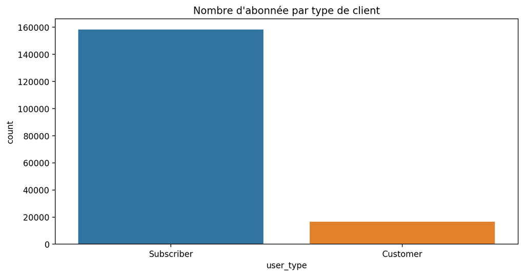

Subscriber : 158206 Customer : 16559

La grande partie des utilisateurs sont des abonnées

### Quelle est la distribution des utilisateur sur le partage tout le trajet ?

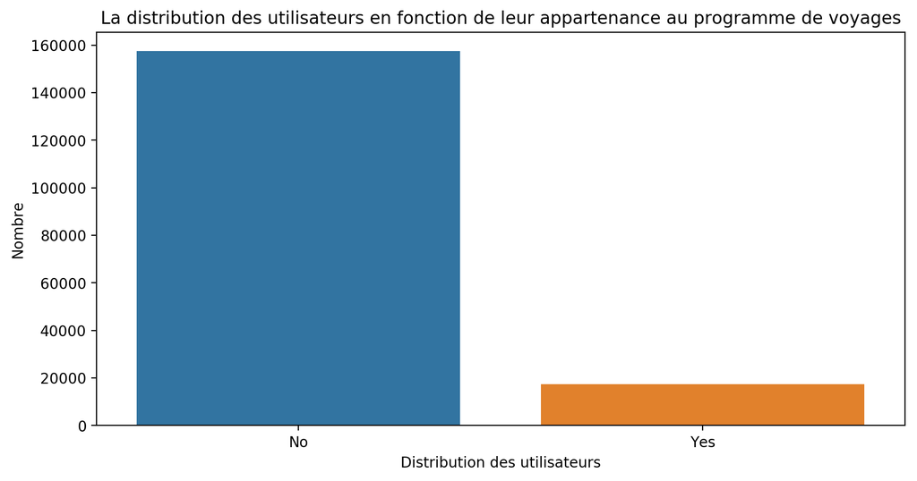

Le graphique ci-dessus montre que la majorité des utilisateurs ne font pas partie du programme de voyages.

### Quelle est la distribution en fonction de l'Age ?

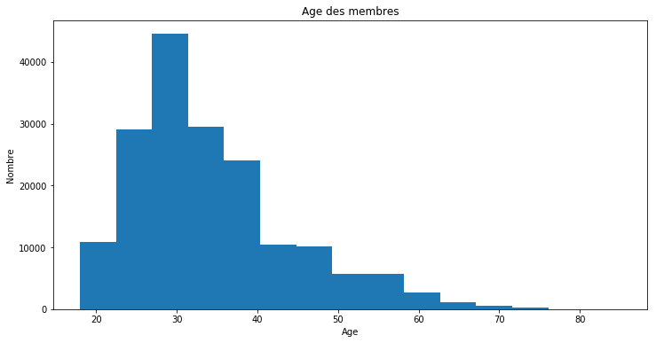

La plupart des utilisateurs de vélo ont environ entre 20 et 50 ans. La majorité a environ 30 ans.

### Quelle est la distribution en fonction du Genre ?

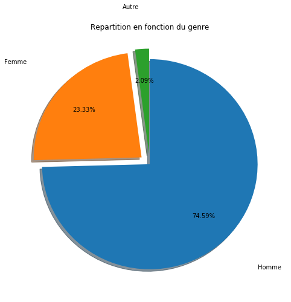

74,59 % des utilisateurs sont des hommes, suivi de 23,33 % de femmes Les autres utilisateurs sont en nombre infime voir 2,09 %

### Quelle est la distribution pour la durée en minute?

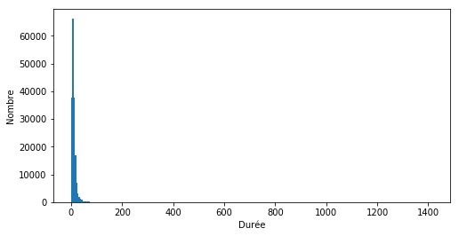

La durée en minutes des trajets est pour la plupart comprise entre 3 min et 16 min ce qui signifie que la plupart des trajets durent moins de 15 minutes !

### Quelle est la distribution pour la durée en heure?

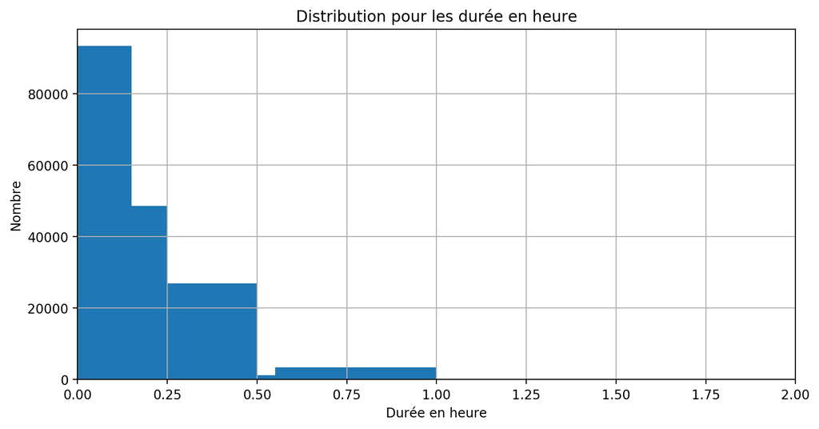

La majorité des trajets sot de moins de 30 min

### Discuss the distribution(s) of your variable(s) of interest. Were there any unusual points? Did you need to perform any transformations?

> - La plupart des utilisateurs de vélo ont environ entre 20 et 50 ans. La majorité a environ 30 ans.
> - L'ensemble de données contient beaucoup d'hommes que de femmes.
> - les abonnés sont plus que des clients
> - La durée en minutes des trajets est pour la plupart comprise entre 3 min et 16 min ce qui signifie que la plupart des trajets durent moins de 15 minutes!

### Of the features you investigated, were there any unusual distributions? Did you perform any operations on the data to tidy, adjust, or change the form of the data? If so, why did you do this?

> - L'attribut d'âge que nous avons ajouté avait des valeurs aberrantes qui peuvent modifier la distribution, j'ai donc limité la tranche d'âge à moins de 85 ans.
> - conversion de la durée en minutes.

## Bivariate Exploration

> In this section, investigate relationships between pairs of variables in your data. Make sure the variables that you cover here have been introduced in some fashion in the previous section (univariate exploration).

### Quelle est la distribution du Type d'utilisateur en fonction du genre ?

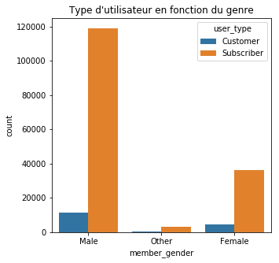

Quelqu'en soit le genre on a plus d'abonné

### Quelle est la distribution de l'age en fonction du genre ?

```
Text(0.5,1,"Repartition en fonction de l'age et du genre ? ")
```

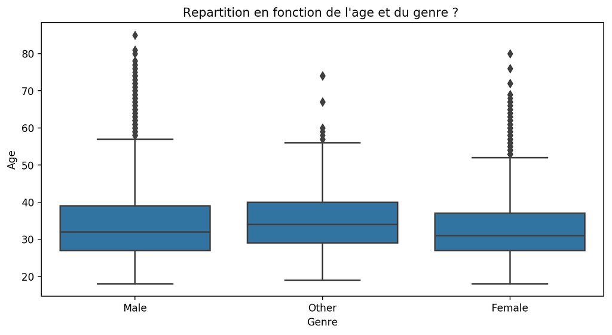

### Quelle est la Durée moyenne du trajet en fonction heure de départ ?

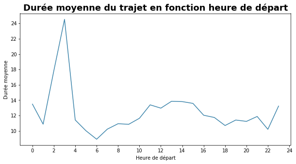

La durée augmente lorsque l'heure de début du trajet se situe entre 1h du matin et 3h du matin.

### quelle est la distribution de la Durée en fonction du type d'utilisateur ?

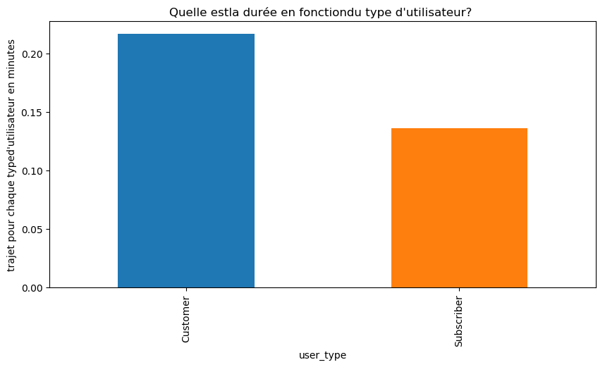

Les clients prenne plus de temps que les abonnés

### Quelle est la distribution de Durée en fonction de l'age ?

```
Text(0.5,1,"Durée en fonction de l'age")
```

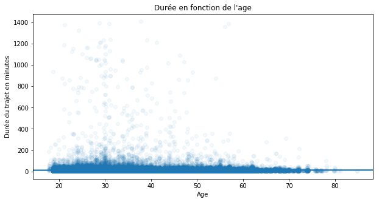

Les personnes entre 20 et 40 ans ont tendance à prendre plus de temps.

### Quelle est la distribution de la Durée en fonction du genre ?

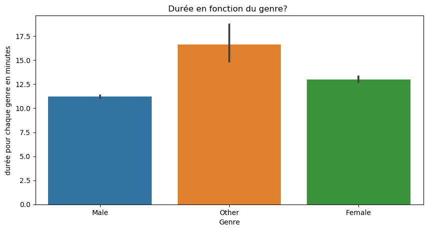

Les temps de trajet plus courts sont pour les utilisateurs masculins.

### Did you observe any interesting relationships between the other features (not the main feature(s) of interest)?

> Les distributions semblent normales et logiques.

## Multivariate Exploration

> Create plots of three or more variables to investigate your data even further. Make sure that your investigations are justified, and follow from your work in the previous sections.

### Quelle est la correlation entre lesdifférentes variables de labase de donnée ?

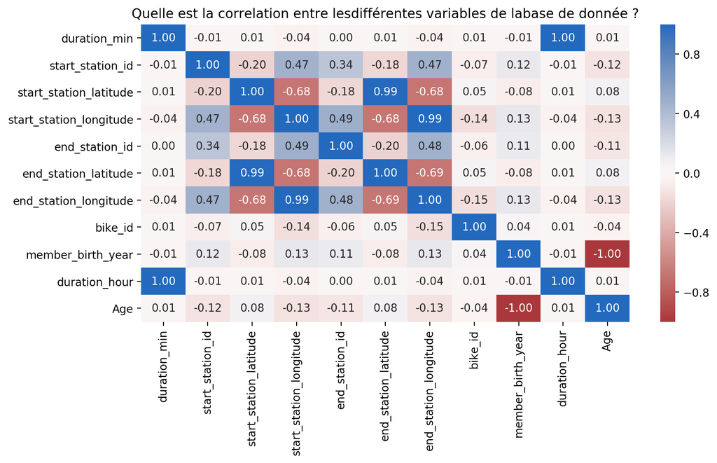

Les graphiques ci-dessus montrent la corrélation entre chaque variable de l'ensemble de données à l'aide de cartes thermiques.

- Il n'y a aucune corrélation pour aucune variable avec le temps (durée en secondes/minutes/heures).
- Il y a une faible corrélation entre start_station_id avec start_station_longitude et end_station_longitude, donc nous pouvons dire que l'emplacement de la station est un bon facteur et que nous pouvons l'étudier dans ma campagne de marketing.
- Il y a une forte corrélation entre la longitude de la station de départ et la longitude de la station d'arrivée, nous pouvons donc dire que l'emplacement de la station est un bon facteur et que nous devons étudier dans ma campagne de marketing.

### Quelle est la distribution de la durée en fonction de l'heure début et type d'utilisateur ?

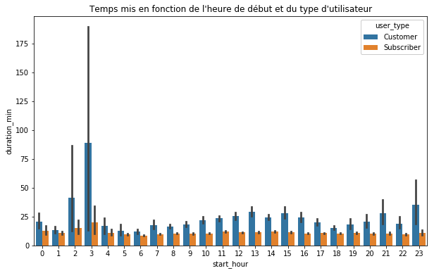

Les clients prenne plus de temps que les abonnés. Entre 2 heures du matin, 3 heures du matin la durée du vélo est plus longue que n'importe quelle heure.

### Quelle est la distribution de la durée en fonction de Âge et chaque type d'utilisateur

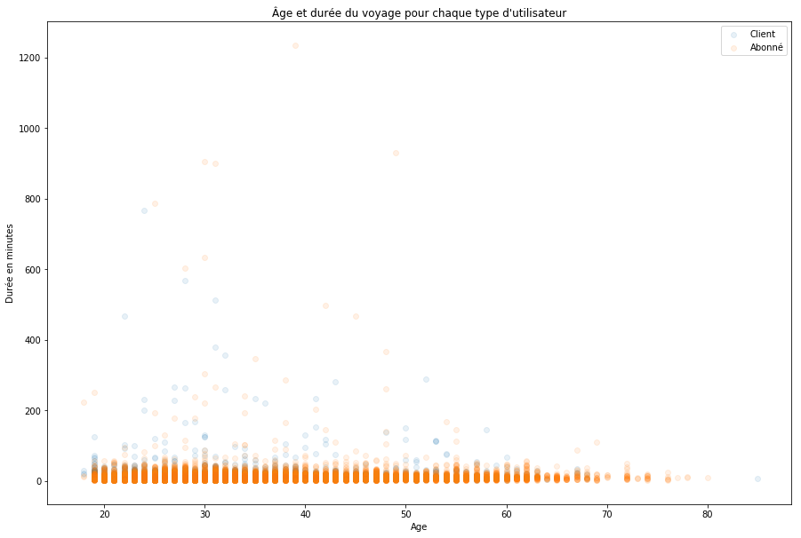

La majorité des utilisateurs plus âgés sont des abonnés et passent peu de temps dans leurs trajets à vélo. La durée des trajets des jeunes clients est légèrement supérieure à celle des abonnés plus jeunes.

### Talk about some of the relationships you observed in this part of the investigation. Were there features that strengthened each other in terms of looking at your feature(s) of interest?

> - Les clients prenne plus de temps que les abonnés. Entre 2 heures du matin, 3 heures du matin la durée du vélo est plus longue que n'importe quelle heure.
> - La majorité des utilisateurs plus âgés sont des abonnés et passent peu de temps dans leurs trajets à vélo. La durée des trajets des jeunes clients est légèrement supérieure à celle des abonnés plus jeunes.

### Were there any interesting or surprising interactions between features?

> no

## Conclusions

> Remove all Tips mentioned above, before you convert this notebook to PDF/HTML

> At the end of your report, make sure that you export the notebook as an html file from the `File > Download as... > HTML or PDF` menu. Make sure you keep track of where the exported file goes, so you can put it in the same folder as this notebook for project submission. Also, make sure you remove all of the quote-formatted guide notes like this one before you finish your report!